# Repuroduction

Naoya Hieda

2017年4月19日

# 3.Emrical Implementation

[Federal Reserve Board charge-off-data](https://www.federalreserve.gov/releases/chargeoff/chgallsa.htm)

## データの読み込みと必要なデータの抜き出し

## 年率換算されているので四半期毎の値に戻して、LGDの値で除算

## 各期の純粋なデフォルト率のデータになっているはず

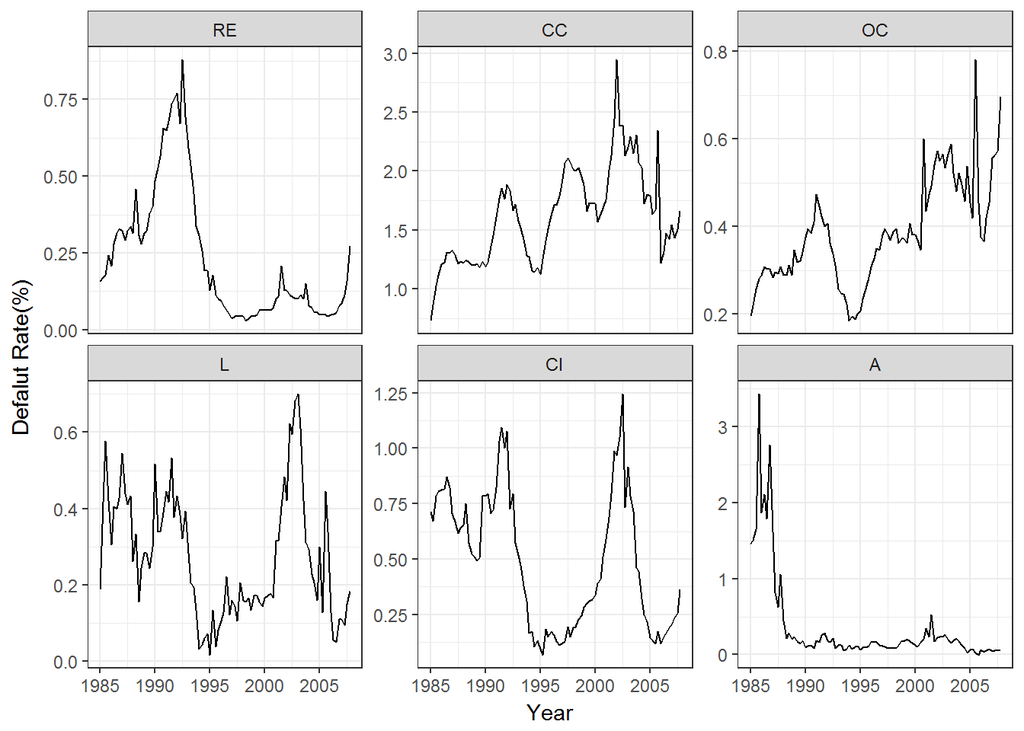

```r
charge_off_data <- read.table('data/N_FRB_CHGDEL.csv',encoding='utf-8',sep=',')


#ネット上とcsvで列の順番が違うので注意
repro_data <- charge_off_data[7:98,c(5,9,10,8,4,3)] %>% apply(2,as.numeric)
colnames(repro_data) <- c('RE','CC','OC','L','CI','A')
#各シリーズのLGD(Loss given defalut を除算) データが年率に変換されているのでそこも修正
LGD <- c(0.35,0.65,0.65,0.45,0.45,0.45)
co_data <- t(repro_data)/4/LGD
co_data <- ts(t(co_data), frequency = 4, start = c(1985,1))
#ちょっと強引に四半期時系列生成
date <- time(co_data) %>% c() %>% as.numeric()
ggplot(co_data %>% melt,aes(x=date[Var1],y=value))+geom_line()+
  facet_wrap(~Var2,scales="free_y",ncol=3)+
  xlab('Year')+ylab('Defalut Rate(%)')
```

```r
colMeans(co_data)
```

```
##        RE        CC        OC         L        CI         A
## 0.2307453 1.6220318 0.3842391 0.2747585 0.4878019 0.3535024
```

```r
sqrt(colMeans(co_data^2)-colMeans(co_data)^2)
```

```
##        RE        CC        OC         L        CI         A
## 0.2131485 0.4029689 0.1181607 0.1622615 0.3051977 0.6013542
```

### 見た目も平均も、論文のものとはちょっとだけずれてしまう

### 元データが、論文のころは四半期でそのまま表示されていたが、現在は各期の値が年率換算されているため。

### ボラティリティは比較的近い値になった

### なぜか2005年4月Aのデフォルト率がマイナス扱いなので、1e-10にしておく

### この後のAに関する計算結果はずっとおかしいけどしょうがない

```r
co_data[co_data<0] <- 1e-10
```

### 元のデータを小数点表示に直してから 単純に標準正規分布cdfの逆数$\Phi^{-1}$で変換したもの

```r
pnorm_co_data <- qnorm(co_data/100)
```

### regression on constant が lm(r ~ 0)で実装できるようなので

```r
Regression_on_constant <- {}
for(i in 1:6){
tmp <- data.frame(y = pnorm_co_data[,i])
fit <- lm(y ~ 0,data=tmp)
Regression_on_constant <- c(Regression_on_constant,list(summary(fit)))
}
```

### 回帰誤差ボラティリティ(残差の標準偏差)

```r
Regression_residual_volatility <- sapply(Regression_on_constant,function(x)sqrt(var(x$residuals)))
```

## beta=0で(24)(25)が成り立っていると考えればいい?

$$\tilde{\theta}_t=\sqrt{\beta}\tilde{\theta}_{t-1}+\frac{(1-\sqrt{\beta})}{\sqrt{1-\rho}}\Phi^{-1}(q)-\frac{\sqrt{\rho}\sqrt{1-\beta}}{\sqrt{1-\rho}}\eta_t\\
\tilde{\theta_t} = \Phi^{-1}(\theta_t)\sim N(\sqrt{\beta}\tilde{\theta}_{t-1}+\frac{(1-\sqrt{\beta})}{\sqrt{1-\rho}}\Phi^{-1}(q),\frac{\rho(1-\beta)}{1-\rho})\\
\\\\
\beta=0のとき,\\
\tilde{\theta}=\frac{1}{\sqrt{1-\rho}}\Phi^{-1}(q)-\frac{\sqrt{\rho}}{\sqrt{1-\rho}}\eta_t\\
\tilde{\theta} = N(\frac{1}{\sqrt{1-\rho}}\Phi^{-1}(q),\frac{\rho}{1-\rho})$$

## ニュートン法で最適化 分散から相関係数$\rho$を推定して、平均から無条件デフォルト確率qを推定する

```r
factor_correlation <- c()
for(sd_2 in Regression_residual_volatility^2){
  f <- function (rho) sd_2 - rho/(1-rho)
  factor_correlation <- c(factor_correlation,uniroot(f,c(0,1-1e-10))$root)
}
un_defalut_rate <- c()
for(i in c(1:6)){
  f <- function (q) qnorm(q)/sqrt(1 - factor_correlation[i]) - colMeans(pnorm_co_data)[i]
  un_defalut_rate <- c(un_defalut_rate,uniroot(f,c(0,1-1e-10))$root)
}
```

## 論文と同じ表形式で表示

```r
table_1 <- t(data.frame(Regression_residual_volatility*100,factor_correlation*100,0,un_defalut_rate*100,0))
colnames(table_1) <-  c('RE','CC','OC','L','CI','A')
rownames(table_1) <- c('Regression_residual_volatility(%)','factor_correlation(%)','std_error_rho(%)','un_defalut_rate(%)','std_error_q(%)')
table_1
```

```
##                                          RE         CC         OC
## Regression_residual_volatility(%) 29.435941 10.0298466 10.4032546
## factor_correlation(%)              7.973782  0.9961047  1.0708570
## std_error_rho(%)                   0.000000  0.0000000  0.0000000
## un_defalut_rate(%)                 0.228818  1.6243253  0.3872353
## std_error_q(%)                     0.000000  0.0000000  0.0000000
##                                            L         CI          A
## Regression_residual_volatility(%) 22.9074896 25.0950250 55.1036666
## factor_correlation(%)              4.9888469  5.9223372 23.2916276
## std_error_rho(%)                   0.0000000  0.0000000  0.0000000
## un_defalut_rate(%)                 0.2840058  0.4967689  0.4965637
## std_error_q(%)                     0.0000000  0.0000000  0.0000000
```

Stderrorはどうやって計算するのか見当がつかなかったので保留

### 自己相関を持つ場合を考えるので(25)の$\beta\neq0$で考える

### 一期前の値に対して線形回帰

```r
Regression_on_constant <- {}
for(i in 1:6){
tmp <- data.frame(y = pnorm_co_data[2:92,i],x = pnorm_co_data[1:91,i])
fit <- lm(y ~ x ,data=tmp)
Regression_on_constant <- c(Regression_on_constant,list(summary(fit)))
}
```

### 回帰誤差ボラティリティ(残差の標準偏差)は先程と同じように取り出せる

### $\beta$は回帰の係数

### $\rho$は分散からの最適化で先ほどと同じ

### qは式が複雑になるが先ほどと同じ

```r
Regression_residual_volatility <- sapply(Regression_on_constant,function(x)sqrt(var(x$residuals)))
beta_ <- sapply(Regression_on_constant,function(x) x$coefficients['x','Estimate']^2)
beta_error <- sapply(Regression_on_constant,function(x) x$coefficients['x','Std. Error'])
factor_correlation <- c()
for(i in 1:6){
  f <- function (rho) sqrt((Regression_residual_volatility[i]^2 - rho*(1-beta_[i])/(1-rho))^2)
  factor_correlation <- c(factor_correlation,optimize(f,c(0,1-1e-10))$minimum)
}
un_defalut_rate <- c()
for(i in c(1:6)){
  f <- function(q)
    -sum(log(dnorm((
      pnorm_co_data[2:92,i]-
        sqrt(beta_[i])*pnorm_co_data[1:91,i]-
        ((1-sqrt(beta_[i]))/sqrt(1-factor_correlation[i]))*qnorm(q))
      )))
  un_defalut_rate <- c(un_defalut_rate,optimize(f, c(0+1e-10,1-1e-10), tol = 0.0001)$minimum)
}

table_2 <- t(data.frame(Regression_residual_volatility*100,factor_correlation*100,0,un_defalut_rate*100,0,beta_*100,beta_error*100))
colnames(table_2) <-  c('RE','CC','OC','L','CI','A')
rownames(table_2) <- c('Regression_residual_volatility(%)','factor_correlation(%)','std_error_rho(%)','un_defalut_rate(%)','std_error_q(%)','beta(%)','std_error_beta(%)')
table_2
```

```
##                                           RE         CC         OC
## Regression_residual_volatility(%)  6.7755476  4.0946427  4.6381591
## factor_correlation(%)              8.6112414  0.6445163  1.0643118
## std_error_rho(%)                   0.0000000  0.0000000  0.0000000
## un_defalut_rate(%)                 0.2955255  1.7075858  0.4364533
## std_error_q(%)                     0.0000000  0.0000000  0.0000000
## beta(%)                           95.1267328 74.1174585 80.0433156
## std_error_beta(%)                  2.4311450  4.3045274  4.8217165
##                                            L         CI          A
## Regression_residual_volatility(%) 14.1575103  7.5642086 48.1931215
## factor_correlation(%)              5.0382766  5.5546383 23.0160879
## std_error_rho(%)                   0.0000000  0.0000000  0.0000000
## un_defalut_rate(%)                 0.2845664  0.4226078  0.4671657
## std_error_q(%)                     0.0000000  0.0000000  0.0000000
## beta(%)                           62.2129027 90.2739247 22.3072101
## std_error_beta(%)                  6.5180415  3.1776928  9.2365317
```

# 4 Factors and Correlations

### $\eta_t$のプロット 式に従って計算

### それっぽいけどy軸が結構違う

式(33)を変換したものと、と式(34)から$\eta_t$を計算
$$\tilde{\theta_t} = \frac{\Phi(q)^{-1} - \sqrt{\rho}X_t}{\sqrt{1-\rho}} から\\
X_t = \frac{\Phi(q)^{-1}-\sqrt{1-\rho}\tilde{\theta_t}}{\sqrt{\rho}} \\
\eta_t = \frac{X_t-\sqrt{\beta}X_{t-1}}{\sqrt{1-\beta}}$$

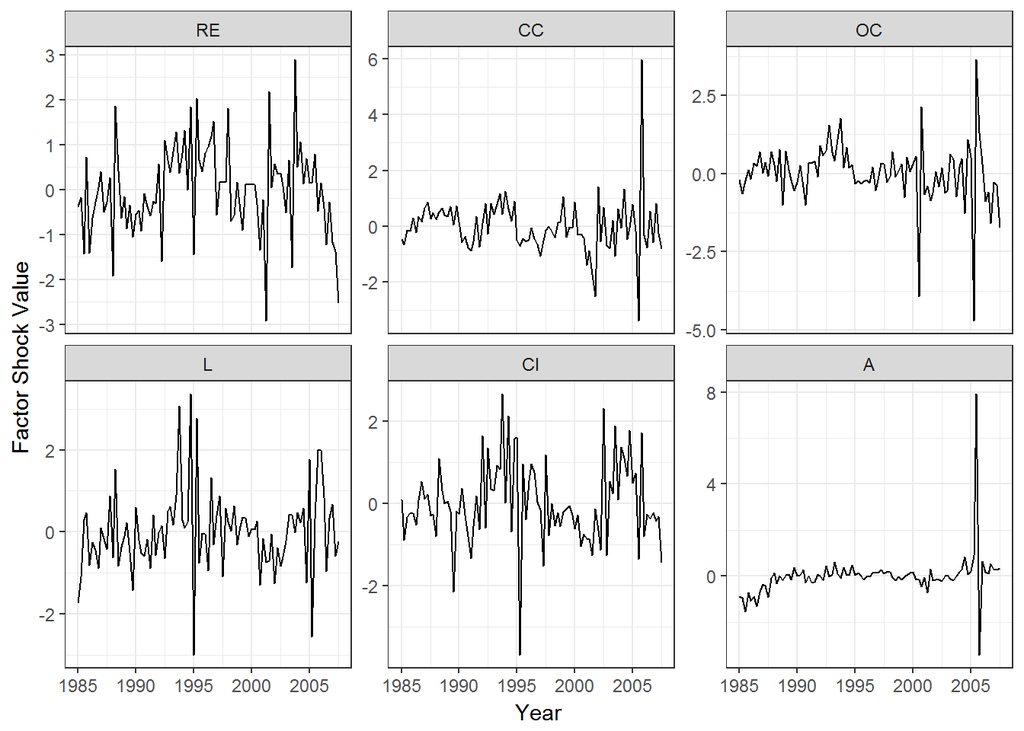

```r
X_t<- t((qnorm(un_defalut_rate)-sqrt(1-factor_correlation)*t(pnorm_co_data))/sqrt(factor_correlation))
plot_d <- t((t(X_t[2:92,])-sqrt(beta_)*t(X_t[1:91,]))/sqrt(1-beta_))


data.frame(dt=date[-length(date)],plot_d) %>% melt(id='dt') %>% ggplot(aes(x=dt,y=value)) + geom_line() + facet_wrap(~variable,ncol=3,scales = 'free_y') + xlab('Year') + ylab('Factor Shock Value')
```